# DATA ANALYSIS IN COMMON BEAN BREEDING PROGRAM - APPROACHES TO DEAL WITH GENETIC AND STATISTICAL IMBALANCES

Deurimar Júnior

18 novembro, 2023

```r
> # rm(list=ls()) # environment cleaning
```

# 1 Required packages

```r
> library(readxl) # reading Excel files
> library(writexl) # rxport Data Frames to Excel 'xlsx' Format
> library(dplyr) # data manipulation
> library(tidyr) # data manipulation
> library(reshape2) # restructure and aggregate data
> library(tibble) # tibble manipulation
> library(magrittr) # code manipulation
> library(knitr) # generate reports that include both code and text
> library(skimr) # get a more organized summary of a dataset
> library(Matrix) # working with dense and sparse matrices
> library(ggplot2) # data visualization
> library(plotly) # data visualization
> library(ggpubr) # data visualization
> library(ComplexHeatmap) # data visualization
> library(RColorBrewer) # manage colors
> library(gghighlight) # ggplot2 extgension to specify as many predicates
> library(circlize) # circular visualization
> library(gridExtra) # work with "grid" graphics
> library(asreml) # data analisys
> library(asremlPlus) # explore ASREML predictions
> # conflicts() # Verificar conflitos de nomes
```

# 2 Data load

```r
> data <- read_excel("data.xlsx")
```

# 3 Data manipulation

## 3.1 Converting any values with Zero or “NAs” into NA

```r
> data[data==0]<-NA # Converting any values with Zero into NA
> data[data=='NA']<-NA # Converting any values with Zero into NA
```

## 3.2 Set the factors

```r
> data[, -ncol(data)] <- lapply(data[, -ncol(data)], factor)
> data$Prod <- as.numeric(data$Prod)
```

## 3.3 Collnames change

```r
> names(data)[1] <- "Genotype"
> names(data)[2] <- "Block"
> names(data)[5] <- "Generation"
> names(data)[6] <- "Yield"
```

# 4 Exploratory analysis

## 4.1 Identifying Variable Types

```r
> str(data)
tibble [2,400 × 6] (S3: tbl_df/tbl/data.frame)
 $ Genotype  : Factor w/ 405 levels "1","10","101",..: 131 231 155 177 131 401 177 405 373 177 ...
 $ Block     : Factor w/ 30 levels "1","2","3","4",..: 3 1 2 3 1 1 1 3 1 2 ...
 $ Rep       : Factor w/ 3 levels "1","2","3": 3 1 2 3 1 1 1 3 1 2 ...
 $ Pop       : Factor w/ 20 levels "1","2","6","7",..: 1 1 1 1 1 1 1 1 1 1 ...
 $ Generation: Factor w/ 4 levels "F4:6","F4:7",..: 1 1 1 1 1 1 1 1 1 1 ...
 $ Yield     : num [1:2400] 6.12 5.99 5.68 5.58 5.21 ...
```

## 4.2 Summary statistics

```r
> summary.yield<-data.frame(data %>%
+                             group_by(Generation)%>%
+                             summarize(Mean = mean(Yield, na.rm=TRUE),
+                                       Median= median(Yield, na.rm=TRUE),
+                                       SD =sd(Yield, na.rm=TRUE),
+                                       Min.=min(Yield, na.rm=TRUE),
+                                       Max.=max(Yield, na.rm=TRUE),
+                                       CV=sd(Yield, na.rm=TRUE)/mean(Yield, na.rm=TRUE)*100,
+                                       St.err= sd(Yield, na.rm=TRUE)/sqrt(length(Yield))
+                             ))
> summary.yield<-data.frame(lapply(summary.yield, function(y) if(is.numeric(y)) round(y, 2) else y))
> summary.yield<-cbind(data.frame(Trait=c(rep("Yield", nrow(summary.yield)))),summary.yield )
```

```r
> kable(summary.yield, caption = "Summary Statistics")
```

Summary Statistics

| Trait | Generation | Mean | Median | SD | Min. | Max. | CV | St.err |
| --- | --- | --- | --- | --- | --- | --- | --- | --- |
| Yield | F4:6 | 4.00 | 4.01 | 0.94 | 0.28 | 7.38 | 23.43 | 0.02 |
| Yield | F4:7 | 3.31 | 3.34 | 1.00 | 0.74 | 6.87 | 30.12 | 0.06 |
| Yield | F4:8 | 3.52 | 3.52 | 0.88 | 1.02 | 5.90 | 25.06 | 0.05 |
| Yield | F4:9 | 2.81 | 2.66 | 0.84 | 0.48 | 5.46 | 29.81 | 0.05 |

## 4.3 Histogram and density curve for Yield in all generations

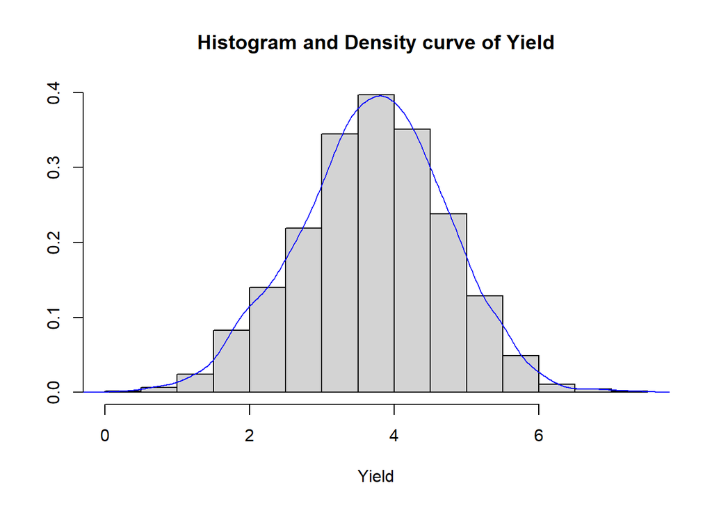

```r
> hist(data$Yield, prob = TRUE, xlab = "Yield",
+      main = "Histogram and Density curve of Yield", ylab = "", na.rm = TRUE)
> lines(density(data$Yield, na.rm = TRUE), col = "blue")
```

## 4.4 Cleveland dot plot - distribution of the data

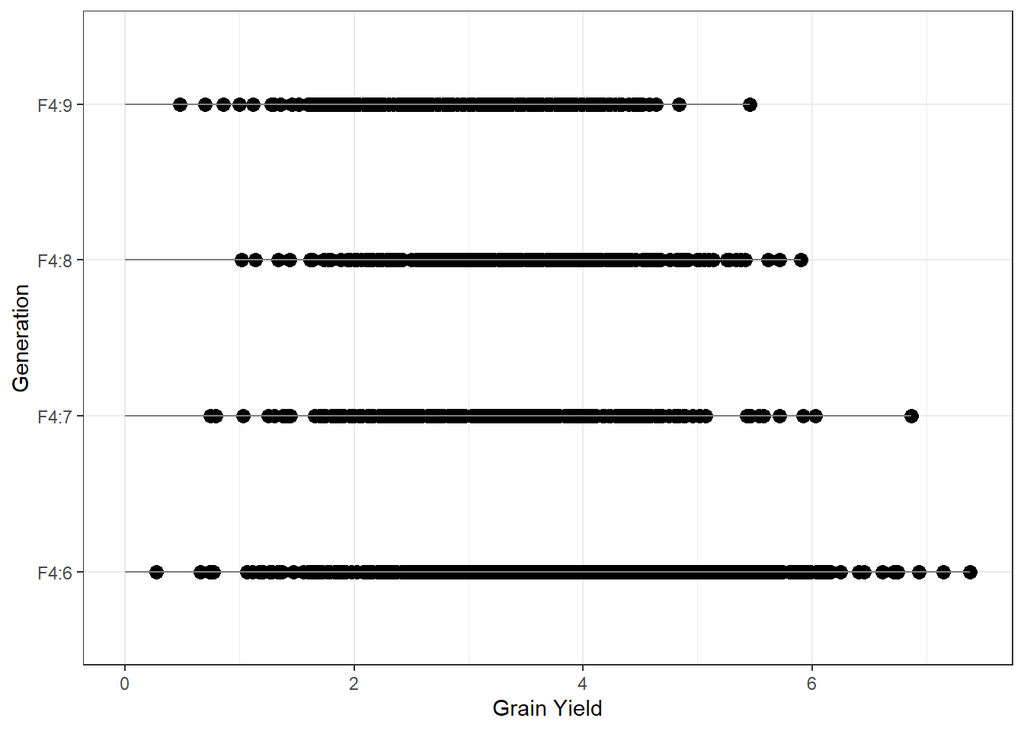

```r
> ggplot(data, aes(x=Yield, y=Generation)) +
+   geom_point(size = 3) + xlab("Grain Yield") +
+   theme_bw() + ylab("Generation") +
+   geom_segment(aes(x=0, xend=Yield, y=Generation, yend=Generation), color='grey50')
```

## 4.5 Box-plot - Yield at different Generations

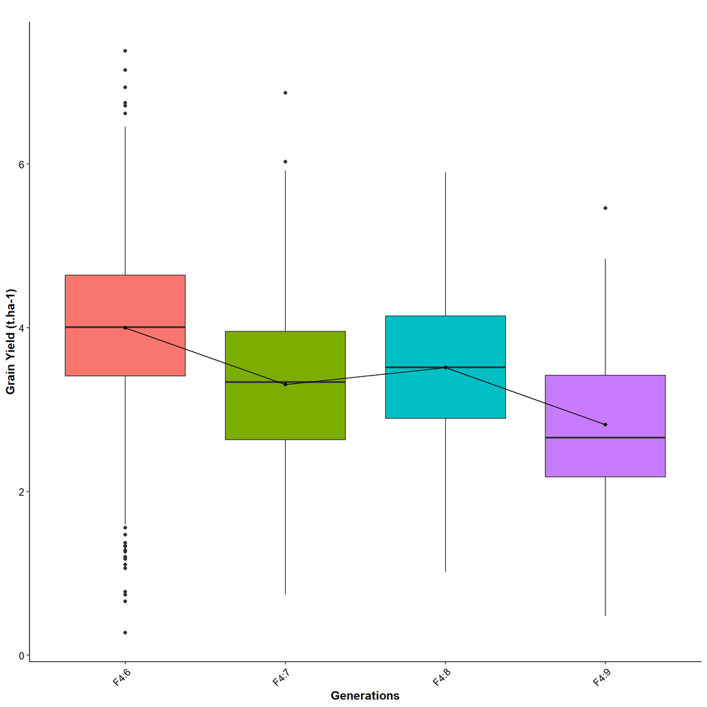

```r
> # First let us visualize the data using boxplots
> myboxplot <- function(dataframe, x, y) {
+   dataframe %>%
+     dplyr::filter(!is.na({{x}}), !is.na({{y}})) %>%
+     ggplot(aes(fill = {{x}}, x = {{x}}, y = {{y}})) +
+     theme_classic() +
+     geom_boxplot() +
+     theme(axis.text.x = element_text(angle = 45, hjust = 1)) +
+     theme(
+       plot.title = element_text(color = "black", size = 12, hjust = 0.5, face = "bold"),
+       axis.title.x = element_text(color = "black", size = 12, face = "bold"),
+       axis.title.y = element_text(color = "black", size = 12, face = "bold")
+     ) +
+     theme(axis.text = element_text(color = "black", size = 10)) +
+     theme(
+       legend.title = element_text(colour = "black", size = 16),
+       legend.position = "none",
+       legend.text = element_text(colour = "black", size = 14)
+     ) +
+     guides(fill = guide_legend(title = "Generations")) +
+     stat_summary(fun = mean, geom = "line", aes(group = 1)) +
+     stat_summary(fun = mean, geom = "point")
+ }
>
> # Now draw the box plot for yield
> p1 <- boxplot.yield <- myboxplot(data, x = Generation, y = Yield) +
+   labs(title = "", x = "Generations", y = "Grain Yield (t.ha-1)")
> p1
```

## 4.6 Bar-plot - Mean Yield by Generation

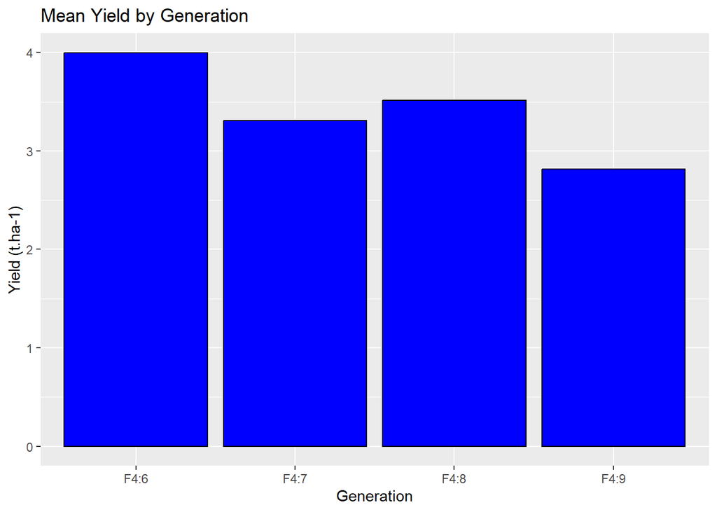

```r
> ggplot(data, aes(x = Generation, y = Yield)) +
+   geom_bar(stat = "summary", fun = "mean", fill = "blue", color = "black", na.rm = TRUE) +
+   labs(y = "Yield (t.ha-1)", x = "Generation", title = "Mean Yield by Generation")
```

## 4.7 Histogram and density curve for Yield by Generation

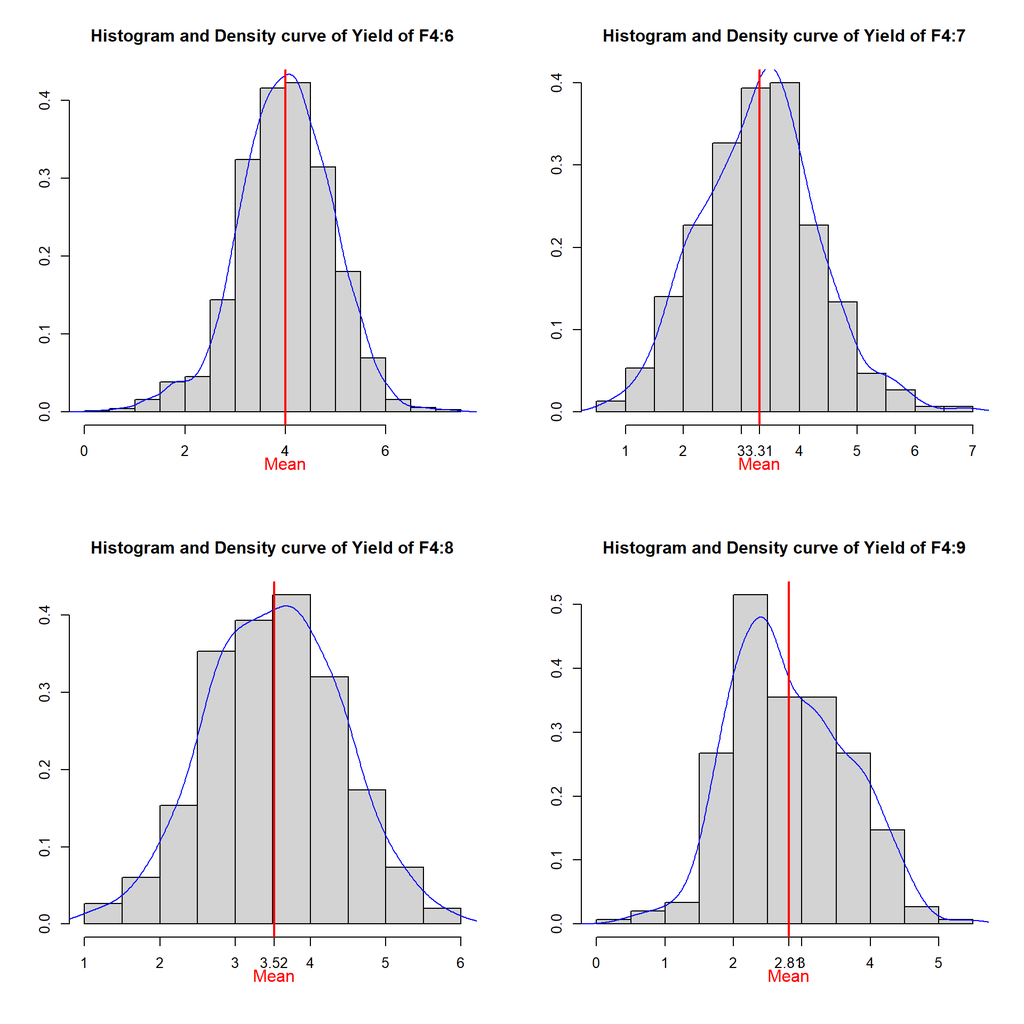

```r
> par(mfrow=c(2,2))
>
> generations <- unique(data$Generation)
>
> for (generation in generations) {
+   subset_data <- data[data$Generation == generation, ]
+
+   mean_value <- round(mean(subset_data$Yield, na.rm = TRUE), 2)
+
+   hist(subset_data$Yield, prob = TRUE, xlab = "",
+        main = paste("Histogram and Density curve of Yield of", generation),
+        ylab = "")
+
+   lines(density(subset_data$Yield, na.rm = TRUE), col = "blue")
+   abline(v = mean_value, col = "red", lwd = 2)
+   axis(1, at = mean_value, labels = mean_value)
+   mtext("Mean", side = 1, at = mean_value, line = 1.8, col = "red")
+ }
```

## 4.8 QQ plots to check normality assumption

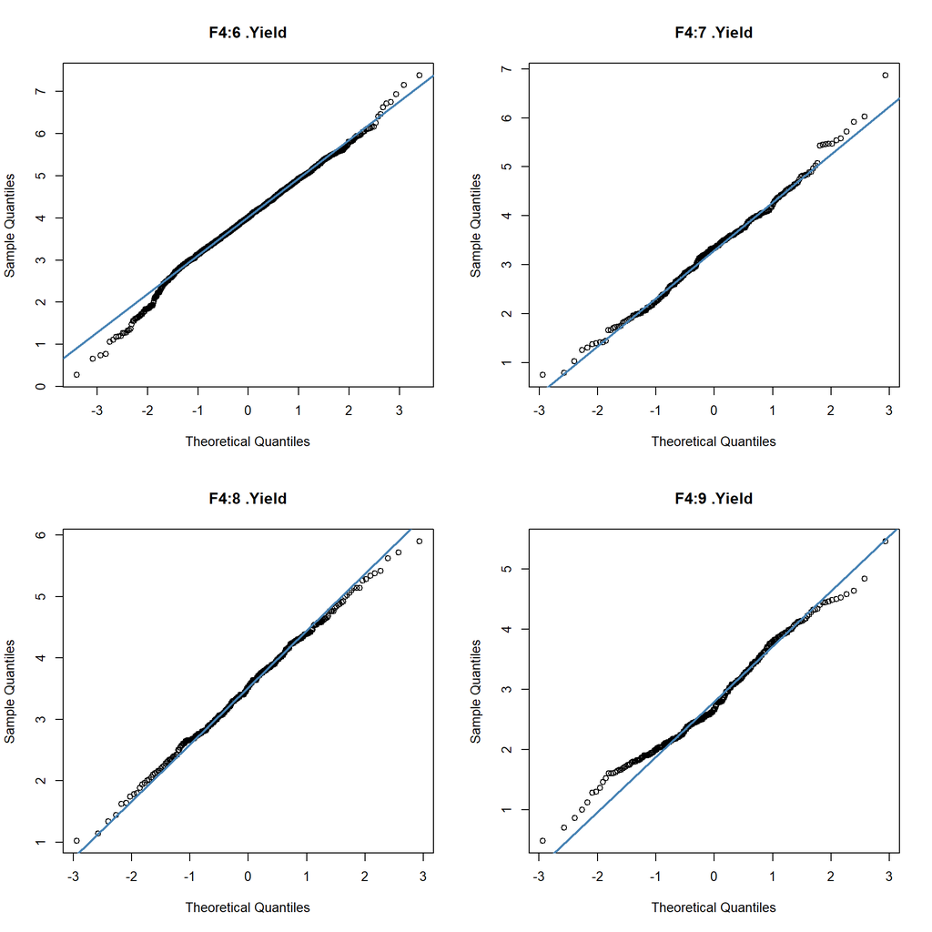

```r
>   par(mfrow=c(2,2))
>   gene<-unique(data$Generation)
>   for(i in 1:length(gene)){
+   level_gene <- data[which(data$Generation==gene[i]),]
+   qqnorm(level_gene$Yield, pch = 1, frame = TRUE,  main=paste(gene[i],".Yield"))
+   qqline(level_gene$Yield, col = "steelblue", lwd = 2)
+   }
```

# 5 Statitical Analysis

## 5.1 Single Trial Analysis

### 5.1.1 BDC - F<sub>4:6</sub>

```r
> DBC = asreml(fixed = Yield  ~ Rep,
+             random = ~ Genotype,
+             residual = ~ units,
+             na.action = na.method(x = "include", y = "include"),
+             data = subset(data, Generation == "F4:6"))
```

**Variance Components - DBC - F4:6**

```r
> vc_DBC <- summary(DBC)$varcomp
> kable(vc_DBC)
```

|  | component | std.error | z.ratio | bound | %ch |
| --- | --- | --- | --- | --- | --- |
| Genotype | 0.3931564 | 0.0373760 | 10.51896 | P | 0 |
| units!R | 0.4079149 | 0.0174234 | 23.41195 | P | 0 |

**BLUP - F4:6**

```r
> pred_DBC <- predict(DBC, classify = "Genotype")$pvals %>%
+   rename(BLUP = predicted.value) %>%
+   mutate(Generation = "F4:6") %>%
+   arrange(desc(BLUP))
```

```r
> head(pred_DBC, 30)
   Genotype     BLUP std.error    status Generation
1       799 5.489286 0.3179886 Estimable       F4:6
2       714 5.407058 0.3179886 Estimable       F4:6
3       510 5.313214 0.3179886 Estimable       F4:6
4       430 5.304050 0.3179886 Estimable       F4:6
5       271 5.269871 0.3179886 Estimable       F4:6
6       597 5.218106 0.3179886 Estimable       F4:6
7       389 5.213277 0.3179886 Estimable       F4:6
8       737 5.189475 0.3179886 Estimable       F4:6
9       723 5.161463 0.3179886 Estimable       F4:6
10      252 5.136770 0.3179886 Estimable       F4:6
 [ reached 'max' / getOption("max.print") -- omitted 20 rows ]
```

### 5.1.2 LATTICE

#### 5.1.2.1 Lattice 1 - F<sub>4:7</sub>

```r
> LTC.1 = asreml(fixed = Yield  ~ Rep,
+             random = ~ Genotype + Block,
+             residual = ~ units,
+             na.action = na.method(x = "include", y = "include"),
+             data = subset(data, Generation == "F4:7"))
```

**Variance Components - Lattice 1 - F<sub>4:7</sub>**

```r
> vc_LTC.1 <- summary(LTC.1)$varcomp
> kable(vc_LTC.1)
```

|  | component | std.error | z.ratio | bound | %ch |
| --- | --- | --- | --- | --- | --- |
| Block | 0.0319066 | 0.0227034 | 1.405364 | P | 0 |
| Genotype | 0.5497081 | 0.0969800 | 5.668265 | P | 0 |
| units!R | 0.3602149 | 0.0386212 | 9.326866 | P | 0 |

**BLUP - F<sub>4:7</sub>**

```r
> pred_LTC.1 <- predict(LTC.1, classify = "Genotype")$pvals %>%
+   rename(BLUP = predicted.value) %>%
+   mutate(Generation = "F4:7") %>%
+   arrange(desc(BLUP))
```

```r
> head(pred_LTC.1, 30)
   Genotype     BLUP std.error    status Generation
1       155 4.895829    0.3221 Estimable       F4:7
2       386 4.659367    0.3221 Estimable       F4:7
3       252 4.503105    0.3221 Estimable       F4:7
4       606 4.406945    0.3221 Estimable       F4:7
5       220 4.296244    0.3221 Estimable       F4:7
6       248 4.292934    0.3221 Estimable       F4:7
7       249 4.278520    0.3221 Estimable       F4:7
8       587 4.197940    0.3221 Estimable       F4:7
9       419 4.175947    0.3221 Estimable       F4:7
10      588 4.104543    0.3221 Estimable       F4:7
 [ reached 'max' / getOption("max.print") -- omitted 20 rows ]
```

#### 5.1.2.2 Lattice 2 - F<sub>4:8</sub>

```r
> LTC.2 = asreml(fixed = Yield  ~ Rep,
+             random = ~ Genotype + Block,
+             residual = ~ units,
+             na.action = na.method(x = "include", y = "include"),
+             data = subset(data, Generation == "F4:8"))
```

**Variance Components - Lattice 8 - F<sub>4:8</sub>**

```r
> vc_LTC.2 <- summary(LTC.2)$varcomp
> kable(vc_LTC.2)
```

|  | component | std.error | z.ratio | bound | %ch |
| --- | --- | --- | --- | --- | --- |
| Block | 0.1285565 | 0.0485516 | 2.647831 | P | 0.4 |
| Genotype | 0.2770687 | 0.0604434 | 4.583936 | P | 0.2 |
| units!R | 0.3761139 | 0.0410457 | 9.163287 | P | 0.0 |

**BLUP - F<sub>4:8</sub>**

```r
> pred_LTC.2 <- predict(LTC.2, classify = "Genotype")$pvals %>%
+   rename(BLUP = predicted.value) %>%
+   mutate(Generation = "F4:8") %>%
+   arrange(desc(BLUP))
```

```r
> head(pred_LTC.2, 30)
   Genotype     BLUP std.error    status Generation
1      vc25 4.572393 0.3097562 Estimable       F4:8
2       194 4.548432 0.3097562 Estimable       F4:8
3       155 4.532805 0.3097562 Estimable       F4:8
4       379 4.517687 0.3097562 Estimable       F4:8
5       161 4.281664 0.3097562 Estimable       F4:8
6       248 4.268542 0.3097562 Estimable       F4:8
7       179 4.254686 0.3097562 Estimable       F4:8
8       587 4.219912 0.3097562 Estimable       F4:8
9       798 4.134166 0.3097562 Estimable       F4:8
10      416 4.127947 0.3097562 Estimable       F4:8
 [ reached 'max' / getOption("max.print") -- omitted 20 rows ]
```

#### 5.1.2.3 Lattice 3 - F<sub>4:9</sub>

```r
> LTC.3 = asreml(fixed = Yield  ~ Rep,
+             random = ~ Genotype + Block,
+             residual = ~ units,
+             na.action = na.method(x = "include", y = "include"),
+             data = subset(data, Generation == "F4:9"))
```

```r
> vc_LTC.9 <- summary(LTC.2)$varcomp
> kable(vc_LTC.2)
```

|  | component | std.error | z.ratio | bound | %ch |
| --- | --- | --- | --- | --- | --- |
| Block | 0.1285565 | 0.0485516 | 2.647831 | P | 0.4 |
| Genotype | 0.2770687 | 0.0604434 | 4.583936 | P | 0.2 |
| units!R | 0.3761139 | 0.0410457 | 9.163287 | P | 0.0 |

**BLUP - F<sub>4:9</sub>**

```r
> pred_LTC.3 <- predict(LTC.3, classify = "Genotype")$pvals %>%
+   rename(BLUP = predicted.value) %>%
+   mutate(Generation = "F4:9") %>%
+   arrange(desc(BLUP))
```

```r
> head(pred_LTC.3, 30)
   Genotype     BLUP std.error    status Generation
1       712 3.941732 0.2945744 Estimable       F4:9
2       419 3.846853 0.2945744 Estimable       F4:9
3       271 3.737678 0.2945744 Estimable       F4:9
4       588 3.688740 0.2945744 Estimable       F4:9
5       252 3.680964 0.2945795 Estimable       F4:9
6       101 3.653411 0.2945744 Estimable       F4:9
7       587 3.638575 0.2945744 Estimable       F4:9
8       786 3.569611 0.2945744 Estimable       F4:9
9       416 3.553949 0.2945795 Estimable       F4:9
10      155 3.543288 0.2945744 Estimable       F4:9
 [ reached 'max' / getOption("max.print") -- omitted 20 rows ]
```

#### 5.1.2.4 Across trials - Lattice

```r
> LTC_DB <- data %>%
+   dplyr::filter(Generation %in% c("F4:7", "F4:8", "F4:9"))
```

```r
> LTC.A = asreml(fixed = Yield  ~ Rep,
+             random = ~ Genotype + Rep:Block,
+             residual = ~ units,
+             na.action = na.method(x = "include", y = "include"),
+             data = LTC_DB)
```

**Variance Components**

```r
> vc_LTC.A <- summary(LTC.A)$varcomp
> kable(vc_LTC.A)
```

|  | component | std.error | z.ratio | bound | %ch |
| --- | --- | --- | --- | --- | --- |
| Rep:Block | 0.0217155 | 0.0138860 | 1.563836 | P | 0 |
| Genotype | 0.2554034 | 0.0471654 | 5.415054 | P | 0 |
| units!R | 0.6414559 | 0.0327604 | 19.580212 | P | 0 |

**BLUPs and Heritability for all trials**

```r
> vc.g <- summary(LTC.A)$varcomp['Genotype','component']
> vc.g
[1] 0.2554034
```

**Mean variance of a difference of two genotypic BLUPs**

```r
> vdBLUP.mat <- predict(LTC.A, classify="Genotype", sed=TRUE)$sed^2
> vdBLUP.avg <- mean(vdBLUP.mat[upper.tri(vdBLUP.mat, diag=FALSE)])
> vdBLUP.avg
[1] 0.1161455
```

**H2 Cullis method**

```r
> H2Cullis <- 1 - (vdBLUP.avg/(vc.g*2))
> H2Cullis
[1] 0.7726234
```

# 6 Multigeneration analysis

Model:
$$y = X\gamma + Z_g u_g + Z_b u_b
+ e$$

For the blocks effect in generations where the experiments were installed in incomplete blocks, the variance-covariance structure for diagonal heterogeneous *G<sub>b</sub>* (DIAG) was used in all models.
$$G_b = \text{DIAG} =
\begin{bmatrix} \sigma_1^2 & 0 & 0 \\ 0 & \sigma_2^2 & 0
\\ 0 & 0 & \sigma_3^2 \end{bmatrix}$$

## 6.1 Identity covariance structure (IDV) for G, variance components for R and Diagonal for B

$$G_g = \text{IDV} = \begin{bmatrix}
\sigma_1^2 & 0 & 0 & 0 \\ 0 & \sigma_1^2 & 0 & 0
\\ 0 & 0 & \sigma_1^2 & 0 \\ 0 & 0 & 0 &
\sigma_1^2 \end{bmatrix}$$
$$R = VC
= \begin{bmatrix} \sigma^2 & 0 & 0 & 0 \\ 0 & \sigma^2
& 0 & 0 \\ 0 & 0 & \sigma^2 & 0 \\ 0 & 0 & 0
& \sigma^2 \end{bmatrix}$$

```r
> M1 = asreml(fixed =  Yield  ~ Generation + Rep:Generation + Pop:at(Generation, "F4:6"),
+             random = ~ Genotype:idv(Generation) + Block:at(Generation, c("F4:7", "F4:8", "F4:9")),
+             residual = ~ units,
+             na.action = na.method(x = "include", y = "include"),
+             data = data)
```

**Variance components, AIC, BIC and Log(L)**

```r
> sum.m1 = summary(M1)$varcomp # Variance components
> aic.m1 = summary(M1)$aic # AIC
> bic.m1 = summary(M1)$bic # BIC
> loglik.m1 = summary(M1)$loglik # LogLik
```

```r
> kable(sum.m1)
```

|  | component | std.error | z.ratio | bound | %ch |
| --- | --- | --- | --- | --- | --- |
| at(Generation, ‘F4:7’):Block | 0.0309986 | 0.0227913 | 1.360111 | P | 0.1 |
| at(Generation, ‘F4:8’):Block | 0.1291382 | 0.0494433 | 2.611842 | P | 0.1 |
| at(Generation, ‘F4:9’):Block | 0.0000000 | NA | NA | B | NA |
| Genotype:Generation!Generation | 0.3500940 | 0.0274409 | 12.758111 | P | 0.1 |
| units!R | 0.3982204 | 0.0141494 | 28.144046 | P | 0.0 |

**Accuracy and heritability**

```r
> mvd.m1 = mean(((predict.asreml(M1,classify = "Genotype:Generation",sed = T)$sed)^2)[
+   upper.tri((predict.asreml(M1,classify = "Genotype:Generation",sed = T)$sed)^2,diag=F)
+ ]) # average pairwise prediction error variance of the genotypes
>
> PEV.m1 = mean(diag((predict.asreml(M1,classify = "Genotype:Generation",vcov = T)$vcov))) # Prediction error variance
> acc.m1 = sqrt(1-(PEV.m1/sum.m1["Genotype","component"])) # Accuracy
> her.m1 = 1-(mvd.m1/(2*sum.m1["Genotype","component"])) # Heritability
```

**BLUPs**

```r
> blup.m1 = predict.asreml(M1,classify = "Genotype:Generation")$pvals # Blups by Generation
> blup.m1.mean = blup.m1 %>% group_by(Genotype) %>%
+   summarise(blup = mean(predicted.value))
```

**Gains**

```r
> gain.m1 = (mean(blup.m1.mean[order(blup.m1.mean$blup,
+                                    decreasing = T),]$blup[1:30])-
+              mean(data$Yield, na.rm=T))/mean(data$Yield, na.rm=T) * 100 # Gain
```

## 6.2 Identity covariance structure (IDV) for G, Diagonal for B and R

$$G_g = \text{IDV} = \begin{bmatrix}
\sigma_1^2 & 0 & 0 & 0 \\ 0 & \sigma_1^2 & 0 & 0
\\ 0 & 0 & \sigma_1^2 & 0 \\ 0 & 0 & 0 &
\sigma_1^2 \end{bmatrix}$$

From here to the last model, the variance-covariance structure adopted for R was the heterogeneous diagonal structure (DIAG)

$$R = \text{DIAG} = \begin{bmatrix}
\sigma_{11}^2 & 0 & 0 & 0 \\ 0 & \sigma_{22}^2 & 0
& 0 \\ 0 & 0 & \sigma_{33}^2 & 0 \\ 0 & 0 & 0
& \sigma_{44}^2 \end{bmatrix}$$

```r
> M2 = asreml(fixed =  Yield  ~ Generation + Rep:Generation + Pop:at(Generation, "F4:6"),
+             random = ~ Genotype:idv(Generation) + Block:at(Generation, c("F4:7", "F4:8", "F4:9")),
+             residual = ~ dsum(~units|Generation),
+             na.action = na.method(x = "include", y = "include"),
+             data = data)
```

**Variance components, AIC, BIC and Log(L)**

```r
> sum.m2 = summary(M2)$varcomp # Variance components
> aic.m2 = summary(M2)$aic # AIC
> bic.m2 = summary(M2)$bic# BIC
> loglik.m2 = summary(M2)$loglik # LogLik
```

```r
> kable(sum.m2)
```

|  | component | std.error | z.ratio | bound | %ch |
| --- | --- | --- | --- | --- | --- |
| at(Generation, ‘F4:7’):Block | 0.0326703 | 0.0231161 | 1.4133121 | P | 0.0 |
| at(Generation, ‘F4:8’):Block | 0.1352982 | 0.0504036 | 2.6842984 | P | 0.0 |
| at(Generation, ‘F4:9’):Block | 0.0066988 | 0.0148530 | 0.4510061 | P | 0.2 |
| Genotype:Generation!Generation | 0.3519308 | 0.0273894 | 12.8491800 | P | 0.0 |
| Generation_F4:6!R | 0.4164335 | 0.0179591 | 23.1879266 | P | 0.0 |
| Generation_F4:7!R | 0.3816360 | 0.0410167 | 9.3044015 | P | 0.0 |
| Generation_F4:8!R | 0.3654238 | 0.0387133 | 9.4392359 | P | 0.0 |
| Generation_F4:9!R | 0.3341416 | 0.0358852 | 9.3113961 | P | 0.0 |

**Accuracy and heritability**

```r
> mvd.m2 = mean(((predict.asreml(M2,classify = "Genotype:Generation",sed = T)$sed)^2)[
+   upper.tri((predict.asreml(M2,classify = "Genotype:Generation",sed = T)$sed)^2,diag=F)
+ ]) # average pairwise prediction error variance of the genotypes
>
> PEV.m2 = mean(diag((predict.asreml(M2,classify = "Genotype:Generation",vcov = T)$vcov))) # Prediction error variance
> acc.m2 = sqrt(1-(PEV.m2/sum.m2["Genotype","component"])) # Accuracy
> her.m2 = 1-(mvd.m2/(2*sum.m2["Genotype","component"])) # Heritability
```

**BLUPs**

```r
> blup.m2 = predict.asreml(M2,classify = "Genotype:Generation")$pvals # Blups by Generation
> blup.m2.mean = blup.m2 %>% group_by(Genotype) %>%
+   summarise(blup = mean(predicted.value))
```

**Gains**

```r
> gain.m2 = (mean(blup.m2.mean[order(blup.m2.mean$blup,
+                                    decreasing = T),]$blup[1:30])-
+              mean(data$Yield, na.rm=T))/mean(data$Yield, na.rm=T) * 100 # Gain
```

## 6.3 Diagonal covariance structure for G, B and R

$$G_g = \text{DIAG} = \begin{bmatrix}
\sigma_{\text{ge}_1}^2 & 0 & 0 & 0 \\ 0 &
\sigma_{\text{ge}_2}^2 & 0 & 0 \\ 0 & 0 &
\sigma_{\text{ge}_3}^2 & 0 \\ 0 & 0 & 0 &
\sigma_{\text{ge}_4}^2 \end{bmatrix}$$

```r
> M3 = asreml(fixed = Yield  ~ Generation + Rep:Generation + Pop:at(Generation, "F4:6"),
+             random = ~ Genotype:at(Generation) + Block:at(Generation, c("F4:7", "F4:8", "F4:9")),
+             residual = ~ dsum(~units|Generation),
+             na.action = na.method(x = "include", y = "include"),
+             data = data)
```

**Variance components, AIC, BIC and Log(L)**

```r
> sum.m3 = summary(M3)$varcomp # Variance components
> aic.m3 = summary(M3)$aic # AIC
> bic.m3 = summary(M3)$bic # BIC
> loglik.m3 = summary(M3)$loglik # LogLik
```

```r
> kable(sum.m3)
```

|  | component | std.error | z.ratio | bound | %ch |
| --- | --- | --- | --- | --- | --- |
| at(Generation, ‘F4:7’):Block | 0.0319066 | 0.0227033 | 1.4053752 | P | 0.0 |
| at(Generation, ‘F4:8’):Block | 0.1284943 | 0.0487228 | 2.6372517 | P | 0.0 |
| at(Generation, ‘F4:9’):Block | 0.0072642 | 0.0150150 | 0.4837961 | P | 0.1 |
| at(Generation, ‘F4:6’):Genotype | 0.3062463 | 0.0342606 | 8.9387383 | P | 0.0 |
| at(Generation, ‘F4:7’):Genotype | 0.5497080 | 0.0969802 | 5.6682468 | P | 0.0 |
| at(Generation, ‘F4:8’):Genotype | 0.2769002 | 0.0605246 | 4.5750037 | P | 0.0 |
| at(Generation, ‘F4:9’):Genotype | 0.3692879 | 0.0697050 | 5.2978717 | P | 0.0 |
| Generation_F4:6!R | 0.4223819 | 0.0184856 | 22.8492605 | P | 0.0 |
| Generation_F4:7!R | 0.3602148 | 0.0386212 | 9.3268670 | P | 0.0 |
| Generation_F4:8!R | 0.3757935 | 0.0409960 | 9.1665862 | P | 0.0 |
| Generation_F4:9!R | 0.3320879 | 0.0361462 | 9.1873612 | P | 0.0 |

**Accuracy and heritability**

```r
> # average pairwise prediction error variance of the genotypes
> mvd.m3 = mean(((predict.asreml(M3,classify = "Genotype:Generation",sed = T)$sed)^2)
+               [upper.tri((predict.asreml(M3,classify = "Genotype:Generation",sed = T)$sed)^2,diag=F)])
>
> # Prediction error variance
> PEV.m3 = mean(diag((predict.asreml(M3,classify = "Genotype:Generation",vcov = T)$vcov)))
>
> acc.m3 = sqrt(1-(PEV.m2/sum.m3[grep('Genotype',rownames(sum.m3)), 1])) # Accuracy
> her.m3 = 1-(mvd.m2/(2*sum.m3[grep('Genotype',rownames(sum.m3)), 1])) # Heritability
> acc.m3.mean = mean(acc.m3, na.rm = T) # Accuracy
> her.m3.mean = mean(her.m3, na.rm = T) # Heritability
```

**BLUPs**

```r
> blup.m3 = predict.asreml(M3,classify = "Genotype:Generation")$pvals # Blups by Generation
> blup.m3.mean = blup.m3 %>% group_by(Genotype) %>%
+   summarise(blup = mean(predicted.value))
```

**Gains**

```r
> gain.m3 = (mean(blup.m3.mean[order(blup.m3.mean$blup,
+                                    decreasing = T),]$blup[1:30])-
+              mean(data$Yield, na.rm=T))/mean(data$Yield, na.rm=T) * 100 # Gain
```

## 6.4 Heterogeneous variance with general correlation matric for G

$$G_g = \text{CORGH} = \begin{bmatrix}
\sigma_{\text{ge}1}^2 & \rho_{12}\sigma_{12}^2 &
\rho_{13}\sigma_{13}^2 & \rho_{14}\sigma_{14}^2 \\
\rho_{12}\sigma_{12}^2 & \sigma_{\text{ge}2}^2 &
\rho_{23}\sigma_{23}^2 & \rho_{24}\sigma_{24}^2 \\
\rho_{13}\sigma_{13}^2 & \rho_{23}\sigma_{23}^2 &
\sigma_{\text{ge}3}^2 & \rho_{34}\sigma_{34}^2 \\
\rho_{14}\sigma_{14}^2 & \rho_{24}\sigma_{24}^2 &
\rho_{34}\sigma_{34}^2 & \sigma_{\text{ge}4}^2 \end{bmatrix}$$

```r
> M4 = asreml(fixed = Yield  ~ Generation + Rep:Generation + Pop:at(Generation, "F4:6"),
+             random = ~ Genotype:corgh(Generation) + Block:at(Generation, c("F4:7", "F4:8", "F4:9")),
+             residual = ~ dsum(~units|Generation),
+             na.action = na.method(x = "include", y = "include"),
+             data = data)
```

**Variance components, AIC, BIC and Log(L)**

```r
> sum.m4 = summary(M4)$varcomp # Variance components
> aic.m4 = summary(M4)$aic # AIC
> bic.m4 = summary(M4)$bic # BIC
> loglik.m4 = summary(M4)$loglik # LogLik
```

```r
> kable(sum.m4)
```

|  | component | std.error | z.ratio | bound | %ch |
| --- | --- | --- | --- | --- | --- |
| at(Generation, ‘F4:7’):Block | 0.0442413 | 0.0247276 | 1.7891494 | P | 0 |
| at(Generation, ‘F4:8’):Block | 0.1451033 | 0.0522403 | 2.7776131 | P | 0 |
| at(Generation, ‘F4:9’):Block | 0.0150400 | 0.0161723 | 0.9299847 | P | 0 |
| Genotype:Generation!Generation!F4:7:!Generation!F4:6.cor | 0.7964705 | 0.0737412 | 10.8008903 | U | 0 |
| Genotype:Generation!Generation!F4:8:!Generation!F4:6.cor | 0.6131741 | 0.1091953 | 5.6153907 | U | 0 |
| Genotype:Generation!Generation!F4:8:!Generation!F4:7.cor | 0.6358827 | 0.0985293 | 6.4537397 | U | 0 |
| Genotype:Generation!Generation!F4:9:!Generation!F4:6.cor | 0.5806349 | 0.1030667 | 5.6335841 | U | 0 |
| Genotype:Generation!Generation!F4:9:!Generation!F4:7.cor | 0.6099100 | 0.0915852 | 6.6594810 | U | 0 |
| Genotype:Generation!Generation!F4:9:!Generation!F4:8.cor | 0.5317891 | 0.1141171 | 4.6600307 | U | 0 |
| Genotype:Generation!Generation_F4:6 | 0.3171725 | 0.0348185 | 9.1092982 | P | 0 |
| Genotype:Generation!Generation_F4:7 | 0.5152153 | 0.0858830 | 5.9990405 | P | 0 |
| Genotype:Generation!Generation_F4:8 | 0.2733823 | 0.0582806 | 4.6907949 | P | 0 |
| Genotype:Generation!Generation_F4:9 | 0.3602435 | 0.0667957 | 5.3932137 | P | 0 |
| Generation_F4:6!R | 0.4202428 | 0.0183272 | 22.9299982 | P | 0 |
| Generation_F4:7!R | 0.3540784 | 0.0375817 | 9.4215585 | P | 0 |
| Generation_F4:8!R | 0.3686538 | 0.0398253 | 9.2567814 | P | 0 |
| Generation_F4:9!R | 0.3256918 | 0.0350503 | 9.2921223 | P | 0 |

**Correlation matrix**

```r
> G.corr.m4 = diag(1, nrow = 4, ncol = 4)
> G.corr.m4[upper.tri(G.corr.m4)] = sum.m4$component[4:9]
> G.corr.m4[lower.tri(G.corr.m4)] = sum.m4$component[4:9]
> G.corr.m4
          [,1]      [,2]      [,3]      [,4]
[1,] 1.0000000 0.7964705 0.6131741 0.5806349
[2,] 0.7964705 1.0000000 0.6358827 0.6099100
[3,] 0.6131741 0.5806349 1.0000000 0.5317891
[4,] 0.6358827 0.6099100 0.5317891 1.0000000
```

**Accuracy and heritability**

```r
> Gvcov = matrix(0, 4, 4)
> Gvcov[upper.tri(Gvcov, diag = T)] = sum.m4[grep('Genotype',rownames(sum.m4)),1]
> Gvcov[lower.tri(Gvcov, diag = F)] = t(Gvcov)[lower.tri(t(Gvcov), diag = F)]
>
> acc.m4 = NULL
> her.m4 = NULL
> for(i in 1:nlevels(data$Generation)){
+   pred_vcov = predict(M4, classify = "Genotype:Generation",
+                       level=list(Generation = i), vcov = T)
+   pred_sed = predict(M4, classify = "Genotype:Generation",
+                      level=list(Generation = i), sed = T)
+   pred_sed$pvals
+   PEV = mean(diag(pred_vcov$vcov))
+   mvd = mean((pred_sed$sed^2)[upper.tri(pred_sed$sed^2,diag = F)])
+   acc.m4[i] = sqrt(1-(PEV/Gvcov[i,i]))
+   her.m4[i] = 1-(mvd/(2*Gvcov[i,i]))
+ }
>
> acc.m4.mean = mean(acc.m4, na.rm = T)
> her.m4.mean = mean(her.m4, na.rm = T)
```

**BLUPs**

```r
> blup.m4 = predict.asreml(M4,classify = "Genotype:Generation")$pvals # Blups by Generation
> blup.m4.mean = blup.m4 %>% group_by(Genotype) %>%
+   summarise(blup = mean(predicted.value))
```

**Gains**

```r
> gain.m4 = (mean(blup.m4.mean[order(blup.m4.mean$blup,
+                                    decreasing = T),]$blup[1:30])-
+              mean(data$Yield, na.rm=T))/mean(data$Yield, na.rm=T) * 100 # Gain
```

**Genetic correlation between Generations (CORGH)**

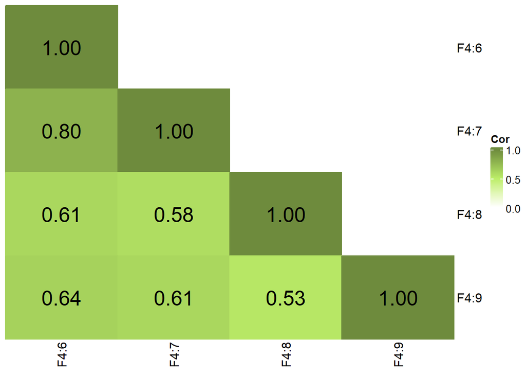

```r
> rownames(G.corr.m4) = colnames(G.corr.m4) = levels(data$Generation)
>
> col_fun = colorRamp2(c(-1,-.5,0,.5,1), c("red4","red1","white",
+                                          "darkolivegreen2","darkolivegreen4"))
>
> Heatmap(G.corr.m4,col=col_fun,
+         rect_gp = gpar(col = "white", lwd = 1, type = "none"),
+         column_dend_height = unit(2, "cm"),
+         row_dend_width = unit(2, "cm"),
+         heatmap_legend_param = list(title="Cor",at=c(0.0,0.5,1.0),
+                                     labels=c("0.0","0.5","1.0")),
+         row_order = rownames(G.corr.m4),
+         column_order = colnames(G.corr.m4),
+         cell_fun = function(j, i, x, y, w, h, fill) {
+           if(i >= j)  grid.rect(x, y, w, h, gp = gpar(fill = fill, col = fill))
+           if(i >= j) grid.text(sprintf("%.2f", G.corr.m4[i, j]), x, y, gp = gpar(fontsize = 20))})
```

## 6.5 Unstructured

$$G_g = \text{US} = \begin{bmatrix}
\sigma_{\text{ge}1}^2 & \sigma_{12}^2 & \sigma_{13}^2 &
\sigma_{14}^2 \\ \sigma_{12}^2 & \sigma_{\text{ge}2}^2 &
\sigma_{23}^2 & \sigma_{24}^2 \\ \sigma_{13}^2 & \sigma_{23}^2
& \sigma_{\text{ge}3}^2 & \sigma_{34}^2 \\ \sigma_{14}^2 &
\sigma_{24}^2 & \sigma_{34}^2 & \sigma_{\text{ge}4}^2
\end{bmatrix}$$

```r
> M5 = asreml(fixed = Yield  ~ Generation + Rep:Generation + Pop:at(Generation, "F4:6"),
+             random = ~ Genotype:us(Generation) + Block:at(Generation, c("F4:7", "F4:8", "F4:9")),
+             residual = ~ dsum(~units|Generation),
+             na.action = na.method(x = "include", y = "include"),
+             data = data)
```

**Variance components, AIC, BIC and Log(L)**

```r
> sum.m5 = summary(M5)$varcomp # Variance components
> aic.m5 = summary(M5)$aic # AIC
> bic.m5 = summary(M5)$bic # BIC
> loglik.m5 = summary(M5)$loglik # LogLik
```

```r
> kable(sum.m5)
```

|  | component | std.error | z.ratio | bound | %ch |
| --- | --- | --- | --- | --- | --- |
| at(Generation, ‘F4:7’):Block | 0.0442411 | 0.0247272 | 1.7891670 | P | 0.0 |
| at(Generation, ‘F4:8’):Block | 0.1451030 | 0.0522398 | 2.7776304 | P | 0.0 |
| at(Generation, ‘F4:9’):Block | 0.0150396 | 0.0161722 | 0.9299669 | P | 0.0 |
| Genotype:Generation!Generation_F4:6:F4:6 | 0.3171688 | 0.0348160 | 9.1098605 | P | 0.0 |
| Genotype:Generation!Generation_F4:7:F4:6 | 0.3219652 | 0.0481270 | 6.6899032 | P | 0.0 |
| Genotype:Generation!Generation_F4:7:F4:7 | 0.5152154 | 0.0858807 | 5.9991979 | P | 0.0 |
| Genotype:Generation!Generation_F4:8:F4:6 | 0.1805569 | 0.0401328 | 4.4989825 | P | 0.0 |
| Genotype:Generation!Generation_F4:8:F4:7 | 0.2386473 | 0.0534839 | 4.4620397 | P | 0.0 |
| Genotype:Generation!Generation_F4:8:F4:8 | 0.2733822 | 0.0582786 | 4.6909532 | P | 0.0 |
| Genotype:Generation!Generation_F4:9:F4:6 | 0.1962664 | 0.0434881 | 4.5131077 | P | 0.1 |
| Genotype:Generation!Generation_F4:9:F4:7 | 0.2627598 | 0.0578453 | 4.5424543 | P | 0.0 |
| Genotype:Generation!Generation_F4:9:F4:8 | 0.1668873 | 0.0456609 | 3.6549252 | P | 0.0 |
| Genotype:Generation!Generation_F4:9:F4:9 | 0.3602439 | 0.0667928 | 5.3934541 | P | 0.0 |
| Generation_F4:6!R | 0.4202438 | 0.0183276 | 22.9295235 | P | 0.0 |
| Generation_F4:7!R | 0.3540785 | 0.0375816 | 9.4215797 | P | 0.0 |
| Generation_F4:8!R | 0.3686539 | 0.0398255 | 9.2567205 | P | 0.0 |
| Generation_F4:9!R | 0.3256920 | 0.0350506 | 9.2920458 | P | 0.0 |

**Correlation matrix**

```r
> Gvcov.m5 = matrix(0, 4, 4)
> Gvcov.m5[upper.tri(Gvcov.m5, diag = T)] = sum.m5[grep('Genotype',rownames(sum.m5)),1]
> Gvcov.m5[lower.tri(Gvcov.m5, diag = F)] = t(Gvcov.m5)[lower.tri(t(Gvcov.m5), diag = F)]
> gencorr.m5= cov2cor(Gvcov.m5)
```

**Accuracy and heritability**

```r
> acc.m5 = NULL
> her.m5 = NULL
> for(i in 1:nlevels(data$Generation)){
+   pred_vcov = predict(M5, classify = "Genotype:Generation",
+                       level=list(Generation = i), vcov = T)
+   pred_sed = predict(M5, classify = "Genotype:Generation",
+                      level=list(Generation = i), sed = T)
+   pred_sed$pvals
+   PEV.m5 = mean(diag(pred_vcov$vcov))
+   mvd.m5 = mean((pred_sed$sed^2)[upper.tri(pred_sed$sed^2,diag = F)])
+   acc.m5[i] = sqrt(1-(PEV.m5/Gvcov.m5[i,i]))
+   her.m5[i] = 1-(mvd.m5/(2*Gvcov.m5[i,i]))
+ }
>
> acc.m5.mean = mean(acc.m5, na.rm = T)
> her.m5.mean = mean(her.m5, na.rm = T)
```

## 6.6 FA1 First-order factor analytic

```r
> M6 = asreml(fixed = Yield  ~ Generation + Rep:Generation + Pop:at(Generation, "F4:6"),
+             random = ~ Genotype:fa(Generation,1) + Block:at(Generation, c("F4:7", "F4:8", "F4:9")),
+             residual = ~ dsum(~units|Generation),
+             na.action = na.method(x = "include", y = "include"),
+             data = data,
+             predict = predict.asreml(classify = "Genotype:Generation"))
```

**Variance components, AIC, BIC and Log(L)**

```r
> sum.m6 = summary(M6)$varcomp # Variance components
> aic.m6 = summary(M6)$aic # AIC
> bic.m6 = summary(M6)$bic # BIC
> loglik.m6 = summary(M6)$loglik # LogLik
```

```r
> kable(sum.m6)
```

|  | component | std.error | z.ratio | bound | %ch |
| --- | --- | --- | --- | --- | --- |
| at(Generation, ‘F4:7’):Block | 0.0440144 | 0.0246722 | 1.7839654 | P | 0 |
| at(Generation, ‘F4:8’):Block | 0.1462819 | 0.0525331 | 2.7845678 | P | 0 |
| at(Generation, ‘F4:9’):Block | 0.0152196 | 0.0162152 | 0.9386024 | P | 0 |
| Genotype:fa(Generation, 1)!F4:6!var | 0.0756281 | 0.0418368 | 1.8076912 | P | 0 |
| Genotype:fa(Generation, 1)!F4:7!var | 0.0948292 | 0.0632479 | 1.4993263 | P | 0 |
| Genotype:fa(Generation, 1)!F4:8!var | 0.1339032 | 0.0456565 | 2.9328374 | P | 0 |
| Genotype:fa(Generation, 1)!F4:9!var | 0.1930818 | 0.0517826 | 3.7286971 | P | 0 |
| Genotype:fa(Generation, 1)!F4:6!fa1 | 0.4917552 | 0.0504097 | 9.7551612 | P | 0 |
| Genotype:fa(Generation, 1)!F4:7!fa1 | 0.6490114 | 0.0730199 | 8.8881494 | P | 0 |
| Genotype:fa(Generation, 1)!F4:8!fa1 | 0.3737870 | 0.0626020 | 5.9708450 | P | 0 |
| Genotype:fa(Generation, 1)!F4:9!fa1 | 0.4085392 | 0.0668991 | 6.1068001 | P | 0 |
| Generation_F4:6!R | 0.4202012 | 0.0183237 | 22.9321300 | P | 0 |
| Generation_F4:7!R | 0.3541520 | 0.0375924 | 9.4208368 | P | 0 |
| Generation_F4:8!R | 0.3681891 | 0.0397556 | 9.2613235 | P | 0 |
| Generation_F4:9!R | 0.3254614 | 0.0350171 | 9.2943635 | P | 0 |

**Matrix of correlations between the factor analytic**

```r
> R = sum.m6$component[4:7] # round
> L1 = sum.m6$component[8:11] # loadings
> (V = L1%*%t(L1)+diag(R))
          [,1]      [,2]      [,3]      [,4]
[1,] 0.3174513 0.3191548 0.1838117 0.2009013
[2,] 0.3191548 0.5160450 0.2425920 0.2651466
[3,] 0.1838117 0.2425920 0.2736200 0.1527067
[4,] 0.2009013 0.2651466 0.1527067 0.3599861
> cov2cor(V)
          [,1]      [,2]      [,3]      [,4]
[1,] 1.0000000 0.7885313 0.6236785 0.5942940
[2,] 0.7885313 1.0000000 0.6455930 0.6151761
[3,] 0.6236785 0.6455930 1.0000000 0.4865654
[4,] 0.5942940 0.6151761 0.4865654 1.0000000
```

**Accuracy and heritability**

```r
> lambda = sum.m6[grep('fa1',rownames(sum.m6)),1]
> psi = diag(sum.m6[grep('var',rownames(sum.m6)),1])
> Gvcov.m6 = lambda %*% t(lambda) + psi
> expvar6 = (sum(diag(lambda %*% t(lambda)))/
+              sum(diag(lambda %*% t(lambda) + psi)))*100
>
> gencorr.m6 = cov2cor(Gvcov.m6)
>
> acc.m6 = NULL
> her.m6 = NULL
> for(i in 1:nlevels(data$Generation)){
+   pred_vcov = predict(M6, classify = "Genotype:Generation",
+                       level=list(Generation = i), vcov = T)
+   pred_sed = predict(M6, classify = "Genotype:Generation",
+                      level=list(Generation = i), sed = T)
+   pred_sed$pvals
+   PEV = mean(diag(pred_vcov$vcov))
+   mvd = mean((pred_sed$sed^2)[upper.tri(pred_sed$sed^2,diag = F)])
+   acc.m6[i] = sqrt(1-(PEV/Gvcov[i,i]))
+   her.m6[i] = 1-(mvd/(2*Gvcov[i,i]))
+ }
>
> acc.m6.mean = mean(acc.m6, na.rm = T)
> her.m6.mean = mean(her.m6, na.rm = T)
```

**BLUPs**

```r
> blup.m6 = predict.asreml(M6,classify = "Genotype:Generation")$pvals # Blups by Generation
> blup.m6.mean = blup.m6 %>% group_by(Genotype) %>%
+   summarise(blup = mean(predicted.value))
```

**Gains**

```r
> gain.m6 = (mean(blup.m6.mean[order(blup.m6.mean$blup,
+                                    decreasing = T),]$blup[1:30])-
+              mean(data$Yield, na.rm=T))/mean(data$Yield, na.rm=T) * 100 # Gain
```

## 6.7 FA2 Second-order factor analytic

```r
> M7 = asreml(fixed = Yield  ~ Generation + Rep:Generation + Pop:at(Generation, "F4:6"),
+             random = ~ Genotype:fa(Generation,2) + Block:at(Generation, c("F4:7", "F4:8", "F4:9")),
+             residual = ~ dsum(~units|Generation),
+             na.action = na.method(x = "include", y = "include"),
+             data = data,
+             predict = predict.asreml(classify = "Genotype:Generation"))
```

**Variance components, AIC, BIC and Log(L)**

```r
> sum.m7 = summary(M7)$varcomp # Variance components
> aic.m7 = summary(M7)$aic # AIC
> bic.m7 = summary(M7)$bic # BIC
> loglik.m7 = summary(M7)$loglik # LogLik
```

```r
> kable(sum.m7)
```

|  | component | std.error | z.ratio | bound | %ch |
| --- | --- | --- | --- | --- | --- |
| at(Generation, ‘F4:7’):Block | 0.0442404 | 0.0247281 | 1.7890695 | P | 0.0 |
| at(Generation, ‘F4:8’):Block | 0.1451031 | 0.0522431 | 2.7774605 | P | 0.0 |
| at(Generation, ‘F4:9’):Block | 0.0150449 | 0.0161777 | 0.9299787 | P | 0.0 |
| Genotype:fa(Generation, 2)!F4:6!var | 0.0682752 | 0.2526391 | 0.2702481 | P | 0.7 |
| Genotype:fa(Generation, 2)!F4:7!var | 0.0968893 | 0.3043427 | 0.3183559 | P | 0.5 |
| Genotype:fa(Generation, 2)!F4:8!var | 0.1283395 | 0.2026228 | 0.6333912 | P | 0.1 |
| Genotype:fa(Generation, 2)!F4:9!var | 0.1627834 | 0.6301477 | 0.2583259 | P | 0.7 |
| Genotype:fa(Generation, 2)!F4:6!fa1 | 0.4989204 | 0.2542056 | 1.9626649 | P | 0.1 |
| Genotype:fa(Generation, 2)!F4:7!fa1 | 0.6453620 | 0.3319952 | 1.9438894 | P | 0.1 |
| Genotype:fa(Generation, 2)!F4:8!fa1 | 0.3619239 | 0.1882033 | 1.9230473 | P | 0.0 |
| Genotype:fa(Generation, 2)!F4:9!fa1 | 0.3934022 | 0.2169306 | 1.8134933 | P | 0.2 |
| Genotype:fa(Generation, 2)!F4:6!fa2 | 0.0000000 | NA | NA | F | NA |
| Genotype:fa(Generation, 2)!F4:7!fa2 | 0.0429372 | 1.4893646 | 0.0288292 | P | 4.5 |
| Genotype:fa(Generation, 2)!F4:8!fa2 | 0.1185793 | 1.3488084 | 0.0879141 | P | 0.2 |
| Genotype:fa(Generation, 2)!F4:9!fa2 | 0.2066543 | 1.2504748 | 0.1652607 | P | 1.7 |
| Generation_F4:6!R | 0.4202364 | 0.0183247 | 22.9327443 | P | 0.0 |
| Generation_F4:7!R | 0.3540784 | 0.0375817 | 9.4215624 | P | 0.0 |
| Generation_F4:8!R | 0.3686543 | 0.0398250 | 9.2568579 | P | 0.0 |
| Generation_F4:9!R | 0.3256869 | 0.0350485 | 9.2924775 | P | 0.0 |

```r
> fa1.loadings = sum.m7[grep('fa1', rownames(sum.m7)),1]
> fa2.loadings = sum.m7[grep('fa2', rownames(sum.m7)),1]
> mat.loadings = as.matrix(cbind(fa1.loadings,fa2.loadings))
> svd.mat.loadings = svd(mat.loadings)
> mat.loadings.star = mat.loadings %*% svd.mat.loadings$v * - 1
> colnames(mat.loadings.star) = c("fa1","fa2")
> psi = diag(sum.m7[grep("var", rownames(sum.m7)),1])
> lamblamb.star = mat.loadings.star %*% t(mat.loadings.star)
> expvar7 = (sum(diag(lamblamb.star))/
+              sum(diag(lamblamb.star + psi)))*100
> Gvcov = mat.loadings.star %*% t(mat.loadings.star) + psi
>
> acc.m7 = NULL
> her.m7 = NULL
> for(i in 1:nlevels(data$Generation)){
+   pred_vcov = predict(M7, classify = "Genotype:Generation",
+                       level=list(Generation = i), vcov = T)
+   pred_sed = predict(M7, classify = "Genotype:Generation",
+                      level=list(Generation = i), sed = T)
+   pred_sed$pvals
+   PEV = mean(diag(pred_vcov$vcov))
+   mvd = mean((pred_sed$sed^2)[upper.tri(pred_sed$sed^2,diag = F)])
+   acc.m7[i] = sqrt(1-(PEV/Gvcov[i,i]))
+   her.m7[i] = 1-(mvd/(2*Gvcov[i,i]))
+ }
>
> acc.m7.mean = mean(acc.m7, na.rm = T)
> her.m7.mean = mean(her.m7, na.rm = T)
```

## 6.8 FA3 Third-order factor analytic

```r
> M8 = asreml(fixed = Yield  ~ Generation + Rep:Generation + Pop:at(Generation, "F4:6"),
+             random = ~ Genotype:fa(Generation,3) + Block:at(Generation, c("F4:7", "F4:8", "F4:9")),
+             residual = ~ dsum(~units|Generation),
+             na.action = na.method(x = "include", y = "include"),
+             data = data,
+             predict = predict.asreml(classify = "Genotype:Generation"))
```

**Variance components, AIC, BIC and Log(L)**

```r
> sum.m8 = summary(M8)$varcomp # Variance components
> aic.m8 = summary(M8)$aic # AIC
> bic.m8 = summary(M8)$bic # BIC
> loglik.m8 = summary(M8)$loglik # LogLik
```

```r
> kable(sum.m8)
```

|  | component | std.error | z.ratio | bound | %ch |
| --- | --- | --- | --- | --- | --- |
| at(Generation, ‘F4:7’):Block | 0.0442415 | 0.0247268 | 1.7892116 | P | 0.0 |
| at(Generation, ‘F4:8’):Block | 0.1451034 | 0.0522391 | 2.7776761 | P | 0.0 |
| at(Generation, ‘F4:9’):Block | 0.0150403 | 0.0161730 | 0.9299632 | P | 0.0 |
| Genotype:fa(Generation, 3)!F4:6!var | 0.0730951 | 0.0770853 | 0.9482364 | P | 0.0 |
| Genotype:fa(Generation, 3)!F4:7!var | 0.0899750 | 0.1089054 | 0.8261757 | P | 0.0 |
| Genotype:fa(Generation, 3)!F4:8!var | 0.1207428 | 0.3802286 | 0.3175531 | P | 0.0 |
| Genotype:fa(Generation, 3)!F4:9!var | 0.1564216 | 0.9693774 | 0.1613630 | P | 0.0 |
| Genotype:fa(Generation, 3)!F4:6!fa1 | 0.4940502 | 0.0818643 | 6.0349915 | P | 0.0 |
| Genotype:fa(Generation, 3)!F4:7!fa1 | 0.6517001 | 0.1126867 | 5.7832908 | P | 0.0 |
| Genotype:fa(Generation, 3)!F4:8!fa1 | 0.3654700 | 0.0767418 | 4.7623320 | P | 0.0 |
| Genotype:fa(Generation, 3)!F4:9!fa1 | 0.3972714 | 0.0979381 | 4.0563514 | P | 0.0 |
| Genotype:fa(Generation, 3)!F4:6!fa2 | 0.0000000 | NA | NA | F | NA |
| Genotype:fa(Generation, 3)!F4:7!fa2 | 0.0230055 | 0.6787380 | 0.0338946 | P | 0.3 |
| Genotype:fa(Generation, 3)!F4:8!fa2 | 0.0205281 | 1.9381361 | 0.0105917 | P | 0.4 |
| Genotype:fa(Generation, 3)!F4:9!fa2 | 0.1677280 | 2.5609658 | 0.0654941 | P | 0.0 |
| Genotype:fa(Generation, 3)!F4:6!fa3 | 0.0000000 | NA | NA | F | NA |
| Genotype:fa(Generation, 3)!F4:7!fa3 | 0.0000000 | NA | NA | F | NA |
| Genotype:fa(Generation, 3)!F4:8!fa3 | 0.1365674 | 1.4945650 | 0.0913760 | P | 0.0 |
| Genotype:fa(Generation, 3)!F4:9!fa3 | 0.1336621 | 1.6059098 | 0.0832314 | P | 0.0 |
| Generation_F4:6!R | 0.4202405 | 0.0183257 | 22.9317694 | P | 0.0 |
| Generation_F4:7!R | 0.3540783 | 0.0375815 | 9.4216012 | P | 0.0 |
| Generation_F4:8!R | 0.3686538 | 0.0398251 | 9.2568152 | P | 0.0 |
| Generation_F4:9!R | 0.3256914 | 0.0350496 | 9.2923081 | P | 0.0 |

```r
> fa1.loadings = sum.m8[grep('fa1', rownames(sum.m8)),1]
> fa2.loadings = sum.m8[grep('fa2', rownames(sum.m8)),1]
> fa3.loadings = sum.m8[grep('fa3', rownames(sum.m8)),1]
> mat.loadings = as.matrix(cbind(fa1.loadings,fa2.loadings,fa3.loadings))
> svd.mat.loadings = svd(mat.loadings)
> mat.loadings.star = mat.loadings %*% svd.mat.loadings$v * - 1
> colnames(mat.loadings.star) = c("fa1","fa2","fa3")
> psi = diag(sum.m8[grep("var", rownames(sum.m8)),1])
> lamblamb.star = mat.loadings.star %*% t(mat.loadings.star)
> expvar8 = (sum(diag(lamblamb.star))/
+              sum(diag(lamblamb.star + psi)))*100
> Gvcov = mat.loadings.star %*% t(mat.loadings.star) + psi
>
> acc.m8 = NULL
> her.m8 = NULL
> for(i in 1:nlevels(data$Generation)){
+   pred_vcov = predict(M8, classify = "Genotype:Generation",
+                       level=list(Generation = i), vcov = T)
+   pred_sed = predict(M8, classify = "Genotype:Generation",
+                      level=list(Generation = i), sed = T)
+   pred_sed$pvals
+   PEV = mean(diag(pred_vcov$vcov))
+   mvd = mean((pred_sed$sed^2)[upper.tri(pred_sed$sed^2,diag = F)])
+   acc.m8[i] = sqrt(1-(PEV/Gvcov[i,i]))
+   her.m8[i] = 1-(mvd/(2*Gvcov[i,i]))
+ }
>
> acc.m8.mean = mean(acc.m8, na.rm = T)
> her.m8.mean = mean(her.m8, na.rm = T)
```

# 7 Model selection

```r
> modsel = data.frame(
+   'Model' = paste0(1:8),
+   "G" = c("ID", "ID","DIAG","CORGH","US","FA1", "FA2", "FA3"),
+   "B" = c("DIAG","DIAG","DIAG","DIAG","DIAG","DIAG","DIAG","DIAG"),
+   "R" = c("ID","DIAG","DIAG","DIAG","DIAG","DIAG","DIAG","DIAG"),
+   'AIC' = c(aic.m1,aic.m2,aic.m3,aic.m4,aic.m5,aic.m6,aic.m7,aic.m8),
+   'BIC' = c(bic.m1,bic.m2,bic.m3,bic.m4,bic.m5,bic.m6,bic.m7,bic.m8),
+   "Accuracy" = c(acc.m1,acc.m2,acc.m3.mean,acc.m4.mean,acc.m5.mean,acc.m6.mean,acc.m7.mean,acc.m8.mean),
+   "Heritability" = c(her.m1, her.m2, her.m3.mean, her.m4.mean,her.m5.mean, her.m6.mean,her.m7.mean,her.m8.mean),
+   "ExpeGain" = c(gain.m1,gain.m2,gain.m3,'-','-',gain.m6,'-','-'),
+   "ExpVar" = c('-','-','-',"-","-",expvar6,expvar7,expvar8)
+ )
```

```r
> kable(modsel)
```

[output not shown]

```r
> mods.asr <- list(M1, M2, M3, M4, M5, M6, M7, M8)
> infoCriteria(mods.asr, IClikelihood = "REML")
  fixedDF varDF NBound      AIC      BIC    loglik
1       0     4      1 1281.796 1304.875 -636.8979
2       0     8      0 1285.389 1331.547 -634.6945
3       0    11      0 1282.347 1345.815 -630.1735
4       0    17      0 1184.087 1282.173 -575.0434
5       0    17      0 1184.087 1282.173 -575.0434
6       0    15      0 1180.429 1266.976 -575.2147
7       0    18      1 1186.087 1289.943 -575.0434
8       0    20      3 1190.087 1305.483 -575.0434
```

# 8 Reliability of each model

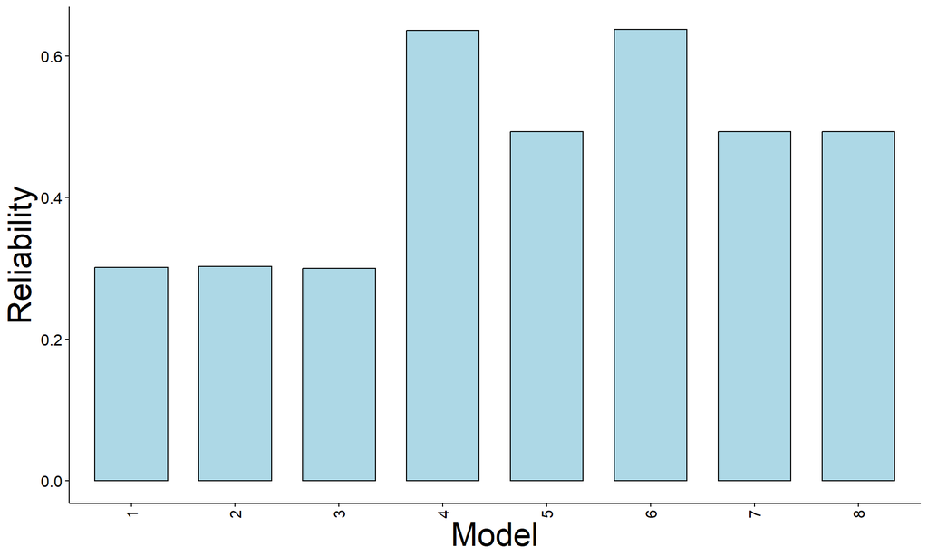

```r
> ggbarplot(modsel, x = "Model", y = "Heritability",
+           fill = "lightblue",           # change fill color by mpg_level
+           color = "black",
+           merge = TRUE,# Set bar border colors to white
+           alette = "jco",            # jco journal color palett. see ?ggpar
+           #sort.by.groups =FALSE,
+           x.text.angle = 90,          # Rotate vertically x axis texts
+           ylab = "Reliability",
+           xlab = FALSE,
+           rotate=FALSE,
+           x.text.col = TRUE,
+           legend = "top",
+           ggtheme =theme_classic() ,
+           font.legend = 14,
+           #legend.title = "Treatment"
+           ) +
+   font("xlab", size = 25, color = "black") +
+   font("ylab", size = 25, color = "black") +
+   font("xy.text", size = 12, color = "black")
```

# 9 Ranking comparison (Spearman correlation)

```r
> rankings = cbind(blup.m1$predicted.value,blup.m2$predicted.value,
+                  blup.m3$predicted.value,blup.m4$predicted.value,blup.m6$predicted.value)
> rownames(rankings) = blup.m1$predicted.value
> colnames(rankings) = c(paste0("Model ",1:5))
>
> corrank = cor(rankings, method = 'spearman')
>
> col_fun = colorRamp2(c(-1,-.5,0,.5,1), c("red4","red1","white",
+                                          "darkolivegreen2","darkolivegreen4"))
>
> heatmap.cor1 <- Heatmap(corrank,col=col_fun,
+         rect_gp = gpar(col = "white", lwd = 1, type = "none"),
+         heatmap_legend_param = list(title="Cor",at=c(0.70,0.85,1),
+                                     labels=c("0.70","0.85","1.00")),
+         row_order = rownames(corrank),
+         column_title = "A",
+         show_heatmap_legend = FALSE,
+         column_order = colnames(corrank),
+         cell_fun = function(j, i, x, y, w, h, fill) {
+           if(i >= j)  grid.rect(x, y, w, h, gp = gpar(fill = fill, col = fill))
+           if(i >= j) grid.text(sprintf("%.2f", corrank[i, j]), x, y, gp = gpar(fontsize = 14))})
```

# 10 Ranking comparison (Spearman correlation)

```r
> rankings = cbind(blup.m1.mean$blup,blup.m2.mean$blup,blup.m3.mean$blup,blup.m4.mean$blup,blup.m6.mean$blup)
> rownames(rankings) = blup.m1.mean$Genotype
> colnames(rankings) = c(paste0("Model ",1:5))
>
> corrank = cor(rankings, method = 'spearman')
>
> col_fun = colorRamp2(c(-1,-.5,0,.5,1), c("red4","red1","white",
+                                          "darkolivegreen2","darkolivegreen4"))
>
> heatmap.cor2 <- Heatmap(corrank,col=col_fun,
+         rect_gp = gpar(col = "white", lwd = 1, type = "none"),
+                 heatmap_legend_param = list(title="Cor",at=c(0.0,0.5,1.0),
+                                     labels=c("0.0","0.5","1.0")),
+         row_order = rownames(corrank),
+         column_title = "B",
+         column_order = colnames(corrank),
+         cell_fun = function(j, i, x, y, w, h, fill) {
+           if(i >= j)  grid.rect(x, y, w, h, gp = gpar(fill = fill, col = fill))
+           if(i >= j) grid.text(sprintf("%.2f", corrank[i, j]), x, y, gp = gpar(fontsize = 14))})
```

```r
> ht_list.1 = heatmap.cor1 + heatmap.cor2
```

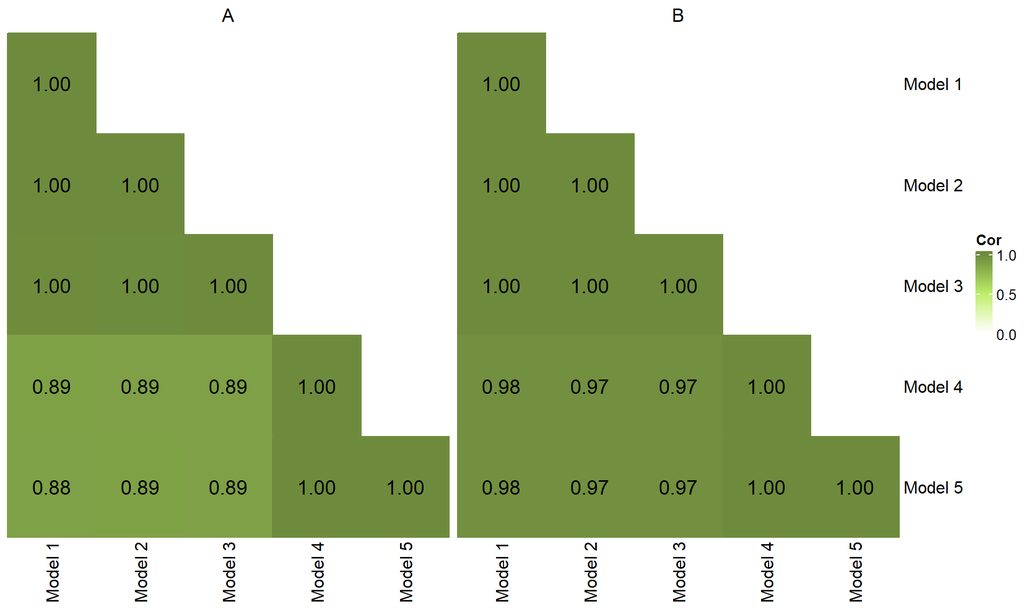

```r
> draw(ht_list.1)
```